# Part I - (Dataset Exploration: Ford go bike trip data)

## Introduction

In this notebook i start with doing general analysis on the data and then i start to plot different visualizations.

## Preliminary Wrangling

```python
# import all packages and set plots to be embedded inline
import numpy as np
import pandas as pd
import matplotlib.pyplot as plt
import seaborn as sns

# For calculating distance between 2 points of logitude and latitude
import haversine as hs
from haversine import Unit

# Setting the style of seaborn
sns.set_theme()
```

```python
# Loading the data and saving as df
df = pd.read_csv("../Datasets/201902-fordgobike-tripdata.csv")
```

```python
# Checking the shape, data types and first 2 rows of the data
print(df.shape)
print("--------------------")
print(df.dtypes)
print("--------------------")
print(df.head(2))
```

```
(183412, 16)
--------------------
duration_sec                 int64
start_time                  object
end_time                    object
start_station_id           float64
start_station_name          object
start_station_latitude     float64
start_station_longitude    float64
end_station_id             float64
end_station_name            object
end_station_latitude       float64
end_station_longitude      float64
bike_id                      int64
user_type                   object
member_birth_year          float64
member_gender               object
bike_share_for_all_trip     object
dtype: object
--------------------
   duration_sec                start_time                  end_time  \
0         52185  2019-02-28 17:32:10.1450  2019-03-01 08:01:55.9750
1         42521  2019-02-28 18:53:21.7890  2019-03-01 06:42:03.0560

   start_station_id                                start_station_name  \
0              21.0  Montgomery St BART Station (Market St at 2nd St)
1              23.0                     The Embarcadero at Steuart St

   start_station_latitude  start_station_longitude  end_station_id  \
0               37.789625              -122.400811            13.0
1               37.791464              -122.391034            81.0

                 end_station_name  end_station_latitude  \
0  Commercial St at Montgomery St             37.794231
1              Berry St at 4th St             37.775880

   end_station_longitude  bike_id user_type  member_birth_year member_gender  \
0            -122.402923     4902  Customer             1984.0          Male
1            -122.393170     2535  Customer                NaN           NaN

  bike_share_for_all_trip
0                      No
1                      No
```

Check for duplicates

```python
# No duplicates
df.duplicated().sum()
```

```
np.int64(0)
```

### What is the structure of your dataset?

1. Numeric columns
   - duration_sec
   - start station id (`Has NANs`)
   - start_station_latitude
   - start_station_longitude
   - end_station_id (`Has NANs`)
   - end_station_latitude
   - end_station_longitude
   - bike_id
   - member_birth_year (`Has NANs`)
2. Objects columns
   - start_time
   - end_time
   - start_station_name (`Has NANs`)
   - end_station_name (`Has NANs`)
   - user_type
   - member_gender (`Has NANs`)
   - bike_share_for_all_trip

### What is/are the main feature(s) of interest in your dataset?

I am interested in most of the features. This is the list of interests

1. Time `duration_sec`
2. Stations information `start_station` & `end_station`
3. Member information `member_gender` & `member_birth_year`
4. User information `user_type`

### What features in the dataset do you think will help support your investigation into your feature(s) of interest?

1. Trip duration in seconds
   - I can create another feature from it to minutes or hours.
2. Stations information
   - I can get information for which stations are most active and more.
3. User information
   - Analysing each user information which would give me deep insight into users
4. Member information
   - Would give me better understanding for members activities which would give me better understandings of customer needs

### Feature Engineering

```python
def convert_to_distance():
    """
    Convert long, lat data pairs to Distance Function
        - This function takes in the data frame and calculates the distance between the start and end stations using the latitude and longitude values.
    ## Parameters:
    No parameters
    ## Output:
    Void function
    """

    distances = []
    iterator = df.shape[0]
    for i in range(iterator):
        distance = get_distance(df['start_station_latitude'][i], df['start_station_longitude'][i], df['end_station_latitude'][i], df['end_station_longitude'][i])
        distances.append(distance)
    distances_Series = pd.Series(distances)
    df['distance'] = distances_Series
def get_distance(lat1, lon1, lat2, lon2):
    """
    Distance Calculation Function
        - This function takes in the latitude and longitude values of two points and returns the distance between them in meters.
    ## Parameters:
    lat1: float
        Latitude of the first point.
    lon1: float
    lat2: float
    lon2: float
    ## Output:
    float
        The distance between the two points in meters.
    """

    loc1=(lat1, lon1)
    loc2=(lat2, lon2)
    return hs.haversine(loc1, loc2, unit=Unit.METERS)


def time_classification(x):
    """
    Time Classification Function
     - This function takes in a time value in seconds and returns a string indicating the classification of the time value.
    ## Parameters:
    x: int
        The time value in seconds.
    ## Output:
    str
        One of the three values: 'Seconds', 'Minutes', 'Hours'
    """

    if(x < 60):
        return 'Seconds'
    elif(x < 3600):
        return 'Minutes'
    else:
        return 'Hours'

def timeConvert_hours(x):
    """
    Time Conversion Function (Hours)
        - This function takes in a time value in seconds and returns the time value in hours.
    ## Parameters:
    x: int
        The time value in seconds.
    ## Output:
    float
        The time value in hours.

    """
    if(x):
        if(x > 3600):
            return x/3600
    else:
        return np.nan

def timeConvert_minutes(x):
    """
    Time Convertion Function (Minutes)
        - This function takes in a time value in seconds and returns the time value in minutes.
    ## Parameters:
    x: int
        The time value in seconds.
    ## Output:
    float
        The time value in minutes.
    """
    if(x):
        if(x < 3600):
            return x/60
    else:
        return np.nan

# Adding new columns to the data frame
# Using apply to loop over rows for each column
df['time_hours'] = df['duration_sec'].apply(timeConvert_hours)
df['time_minutes'] = df['duration_sec'].apply(timeConvert_minutes)

# Using the time_classification function to classify the time
df['time_classification'] = df['duration_sec'].apply(time_classification)

# Calculating the age of the members
df['age'] = df['member_birth_year'].apply(lambda x: 2025 - x)

# Converting the age column to integer (Function Call)
convert_to_distance()

# Converting both columns to datetime
df['start_time'] = pd.to_datetime(df['start_time'])
df['end_time'] = pd.to_datetime(df['end_time'])

# Extracting the day of the week from the start time
df['start_day'] = df['start_time'].dt.day_name()
df['end_day'] = df['end_time'].dt.day_name()

# Extracting the month from the start time
df['start_month'] = df['start_time'].dt.month_name()

# Extracting the hour from the start time
df['start_hour'] = df['start_time'].dt.hour
df['end_hour'] = df['end_time'].dt.hour

# Extracting the year from the start time
df['start_year'] = df['start_time'].dt.year

df['avg_speed'] = df['distance'] / df['duration_sec']
```

## Univariate Exploration

#### Question

What is the range and are there outliers for each of the following?

1. Members birth years
2. Time of trip duration in minutes
3. Time of trip duration in hours

#### Vizualization

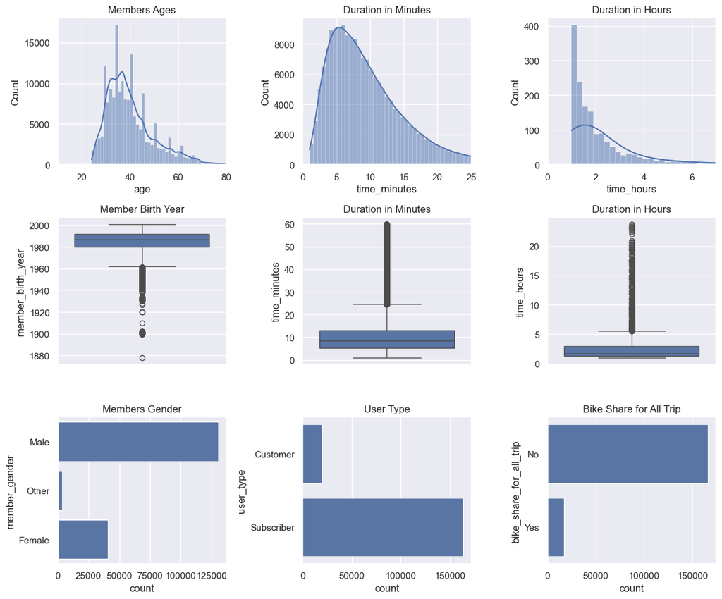

```python
fig, axes = plt.subplots(3, 3, figsize=(12, 10))  # 2 rows and 2 columns
ax_flat = axes.flatten()  # Convert axes to a 1D array.

# Histograms
sns.histplot(df['age'], bins=100, ax=ax_flat[0], kde=True)
ax_flat[0].set_title('Members Ages')
ax_flat[0].set_xlim(10, 80)

sns.histplot(df['time_minutes'], bins=100, ax=ax_flat[1], kde=True)
ax_flat[1].set_title('Duration in Minutes')
ax_flat[1].set_xlim(0, 25)

sns.histplot(df['time_hours'], bins=100, ax=ax_flat[2], kde=True)
ax_flat[2].set_title('Duration in Hours')
ax_flat[2].set_xlim(0, 7)

# Box Plots
sns.boxplot(df['member_birth_year'], ax=ax_flat[3])
ax_flat[3].set_title('Member Birth Year')

sns.boxplot(df['time_minutes'], ax=ax_flat[4])
ax_flat[4].set_title('Duration in Minutes')

sns.boxplot(df['time_hours'], ax=ax_flat[5])
ax_flat[5].set_title('Duration in Hours')


# Count Plots
sns.countplot(df['member_gender'], ax=ax_flat[6])
ax_flat[6].set_title('Members Gender')

sns.countplot(df['user_type'], ax=ax_flat[7])
ax_flat[7].set_title('User Type')

sns.countplot(df['bike_share_for_all_trip'], ax=ax_flat[8])
ax_flat[8].set_title('Bike Share for All Trip')


plt.tight_layout()  # Adjusts subplot parameters to fit the figure area.
plt.show()
```

#### Observations

1. Members
   - For members ages the range is between 20s and 40s, there are some outliers.
   - Great amount of the members are males.
2. Time
   - Most trips durations (in hours) are between 1 and 3 hours. However, there are many outliers.
   - Most trips durations (in minutes) are between 5 to 15 minutes. However, there are also many outliers.
3. Users
   - Great amount of users are subscribers.
   - Only few amount of users do bike sharing

#### Questions

1. What is the distance distribution for trips?
2. What is the number of trips less than one hour?

#### Vizualization

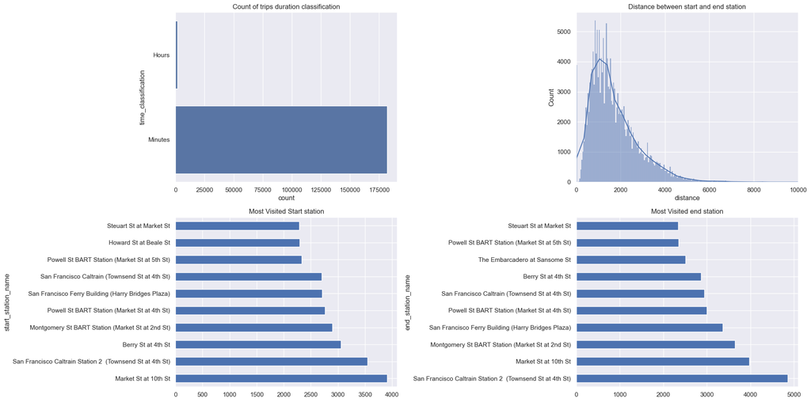

```python
figs, ax = plt.subplots(2, 2, figsize=(12, 5))

# Flattening the axes so i can index them in 1 dimension
ax_flat = ax.flatten()

# Count plot for time_classification
sns.countplot(df['time_classification'], ax=ax_flat[0])
ax_flat[0].set_title("Count of trips duration classification")

# Histogram plot for start_day
sns.histplot(df['distance'], ax=ax_flat[1], kde=True)
ax_flat[1].set_title('Distance between start and end station')
ax_flat[1].set_xlim(0, 10000)

# Using plain matplotlib for the horizontal bar plots
df['start_station_name'].value_counts(ascending=False).head(10).plot(kind='barh', title='Most Visited Start station', ax=ax_flat[2], figsize=(20, 10))
df['end_station_name'].value_counts(ascending=False).head(10).plot(kind='barh', title='Most Visited end station', ax=ax_flat[3], figsize=(20, 10))

# For giving space between the plots
plt.tight_layout()
```

Time classification percentages

```python
# Normalize to get the percentage
df['time_classification'].value_counts(normalize=True)
```

```
time_classification
Minutes    0.990677
Hours      0.009323
Name: proportion, dtype: float64
```

#### Observations

1. Time
   - `99%` of the trips don't exceed 1 hour.
2. Distance
   - The trips distances is between `1km` and `3km`
3. Start Stations
   - The most visited start station is `Market St at 10th St`
4. End Stations
   - The most visited end station is `San Francisco Caltrain Station 2`

### Discuss the distribution(s) of your variable(s) of interest. Were there any unusual points? Did you need to perform any transformations?

#### Unusual point

1. That the majority of the trips were less than one hour.

### Of the features you investigated, were there any unusual distributions? Did you perform any operations on the data to tidy, adjust, or change the form of the data? If so, why did you do this?

This is a list of operations done on the dataset

1. Converting positional points
   - Converted the Start Station(long, lat) End Station(long lat) points into distance in meters. Done using the `convert_to_distance` & `get_distance` functions.
2. Time Conversions
   - Converted time in seconds to hours into new `time_hours` column. Utilized the `timeConvert_hours` function.
   - Also converted time in seconds to minutes if its less than an hour. Used the `timeConvert_minutes`.
3. Classified trips
   - Classified trips according to duration, so i created another column that has values of "Minutes" or "Hours". Done using the `time_classification` function.
4. Created `age` column from `member_birth_year` using lambda funtion.
5. Converted to datetime
   - Converted `start_time` & `end_time` to datetime format.

## Bivariate Exploration

#### Question

1. What is the relation between time and distances & duration with trip date?

#### Visualization

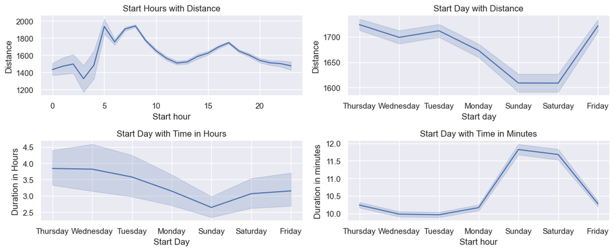

```python
figs, ax = plt.subplots(2, 2, figsize=(12, 5))

ax_flat = ax.flatten()

# Line plot between start_hour and distance
sns.lineplot(x='start_hour', y='distance', data=df, ax=ax_flat[0])
ax_flat[0].set_title('Start Hours with Distance')
ax_flat[0].set_xlabel('Start hour')
ax_flat[0].set_ylabel('Distance')

# Line plot between start_day and distance
sns.lineplot(x='start_day', y='distance', data=df, ax=ax_flat[1])
ax_flat[1].set_title('Start Day with Distance')
ax_flat[1].set_xlabel('Start day')
ax_flat[1].set_ylabel('Distance')

# Line plot between start_day and time_hours
sns.lineplot(x='start_day', y='time_hours', data=df, ax=ax_flat[2])
ax_flat[2].set_title('Start Day with Time in Hours')
ax_flat[2].set_xlabel('Start Day')
ax_flat[2].set_ylabel('Duration in Hours')

# Line plot between start_day and time_minutes
sns.lineplot(x='start_day', y='time_minutes', data=df, ax=ax_flat[3])
ax_flat[3].set_title('Start Day with Time in Minutes')
ax_flat[3].set_xlabel('Start hour')
ax_flat[3].set_ylabel('Duration in minutes')

plt.tight_layout()
```

#### Observations

1. Start hour vs Distance
   - The highest distances of trips made were at hour 5.
   - The lowest are between 2,4.
2. Start day vs Distance
   - The lowest distances covered by users were on Sundays and Saterdays.
   - The highest are on Thursdays and Fridays.
3. Start day vs Trip Duration (In hours)
   - The trips durations are on Sundays.
   - The highest are on Thursdays.
4. Start day vs Trip Duration (In minutes)
   - The highest durations are on Sundays and Saturdays

#### Question

1. What is the relation between duration of trips & member gender?
2. What is the relation between duration of trips & user type?

#### Visualiztion

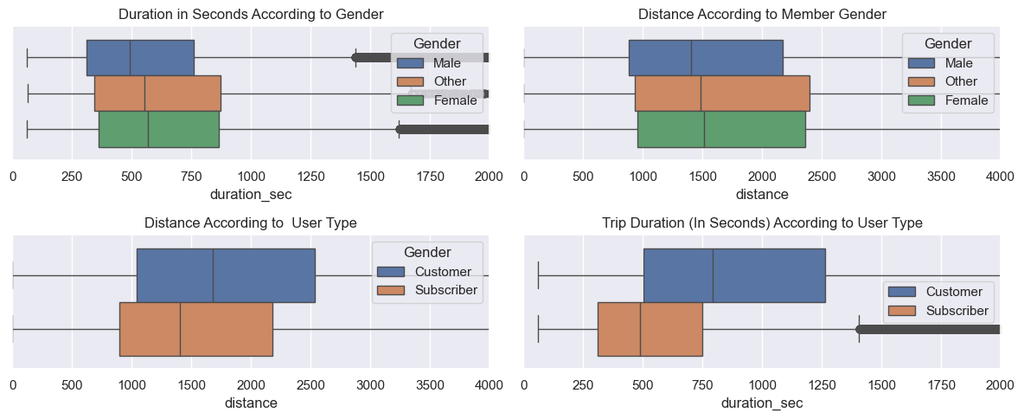

```python
figs, ax = plt.subplots(2, 2, figsize=(12, 5))

ax_flat = ax.flatten()

# Box plots of duration_sec with second variable which is member's gender
sns.boxplot(data=df, x='duration_sec',hue='member_gender', ax=ax_flat[0])
ax_flat[0].set_xlim(0, 2000)
ax_flat[0].set_title("Duration in Seconds According to Gender")
ax_flat[0].legend(title='Gender', loc='upper right')

sns.boxplot(data=df, x='distance',hue='member_gender', ax=ax_flat[1])
ax_flat[1].set_xlim(0, 4000)
ax_flat[1].set_title("Distance According to Member Gender")
ax_flat[1].legend(title='Gender', loc='upper right')

# Box plots of duration_sec with second variable which is user_type
sns.boxplot(data=df, x='distance',hue='user_type', ax=ax_flat[2])
ax_flat[2].set_xlim(0, 4000)
ax_flat[2].set_title("Distance According to  User Type")
ax_flat[2].legend(title='Gender', loc='upper right')

sns.boxplot(data=df, x='duration_sec',hue='user_type', ax=ax_flat[3])
ax_flat[3].set_xlim(0, 2000)
ax_flat[3].set_title("Trip Duration (In Seconds) According to User Type")
ax_flat[3].legend(title='Gender', loc='upper right')

plt.legend()
plt.tight_layout()
```

#### Question

1. What is the relation between user type / member gender and the start day of trips?
2. What is the relation between user type / member gender and bike share for all trips?

#### Visualization

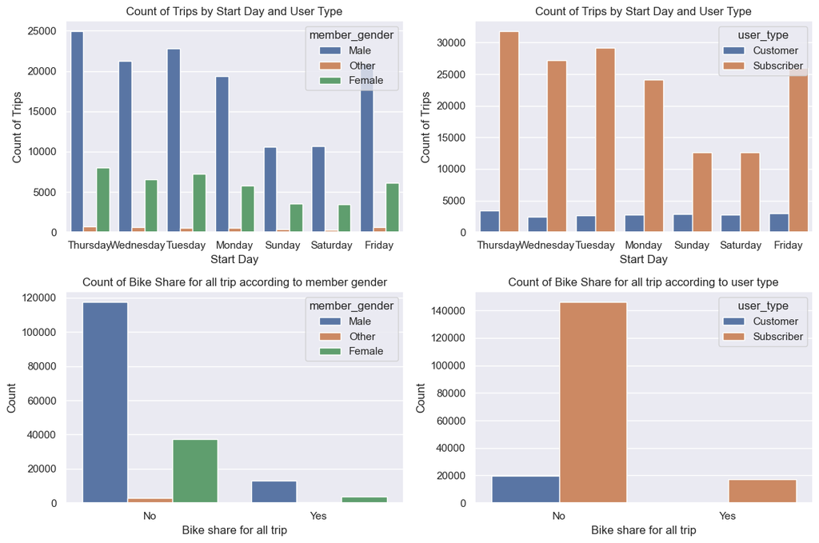

```python
figs, ax = plt.subplots(2, 2, figsize=(12, 8))

ax_flat = ax.flatten()

# Count plots of start_day with second variable which is member's gender and user_type
sns.countplot(data=df, x='start_day', hue='member_gender', ax=ax_flat[0])
ax_flat[0].set_title('Count of Trips by Start Day and User Type')
ax_flat[0].set_xlabel('Start Day')
ax_flat[0].set_ylabel('Count of Trips')

sns.countplot(data=df, x='start_day', hue='user_type', ax=ax_flat[1])
ax_flat[1].set_title('Count of Trips by Start Day and User Type')
ax_flat[1].set_xlabel('Start Day')
ax_flat[1].set_ylabel('Count of Trips')

sns.countplot(data=df, x='bike_share_for_all_trip', hue='member_gender', ax=ax_flat[2])
ax_flat[2].set_title('Count of Bike Share for all trip according to member gender')
ax_flat[2].set_xlabel('Bike share for all trip')
ax_flat[2].set_ylabel('Count')

sns.countplot(data=df, x='bike_share_for_all_trip', hue='user_type', ax=ax_flat[3])
ax_flat[3].set_title('Count of Bike Share for all trip according to user type')
ax_flat[3].set_xlabel('Bike share for all trip')
ax_flat[3].set_ylabel('Count')

plt.tight_layout()
```

#### Observations

1. Count of trips by start day and user type
   - Men have much higher number of trips than women, and the largest number of trips is on Thursdays.
2. Counts of trips by start day and user type
   - Subscribers tend to have much higher number of trips than user type. The highest number also on Thursday.
3. Counts of bike share for all trip according to member gender
   - Great number of members don't bike share, the majority of them are men.
4. Count of bike share for all trip according to user type
   - Great number of users don't bike share, the majority of them are Subscribers.

### Did you observe any interesting relationships between the other features (not the main feature(s) of interest)?

The majority of bike sharing users are male subscribers.

## Multivariate Exploration

#### Question

1. What is the relation age and average speed for each user type and member gender?

#### Visualization

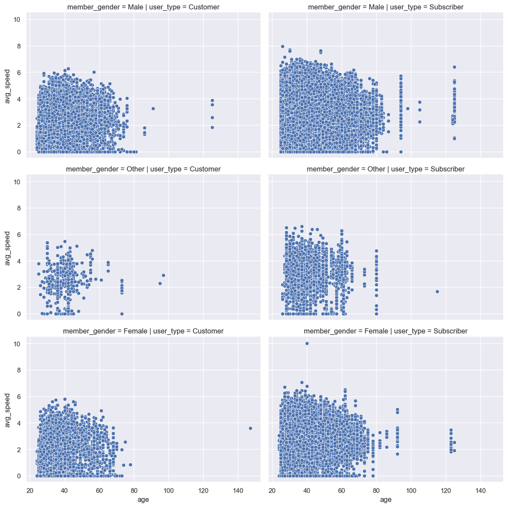

```python
g = sns.FacetGrid(df,
                  col="user_type",
                  row="member_gender",
                  height=4,
                  aspect=1.5)
g.map(sns.scatterplot, "age", "avg_speed")
plt.show()
```

#### Observation

There is no a specific relation. However, the cluster of points show that according to age the average speed for each trip may varry.

#### Question

1. What is the relation between duration in hours vs distance according to user types?
2. What is the relation between duration in minutes vs distance according to member gender?

#### Visualization

```
(0.0, 10000.0)
```

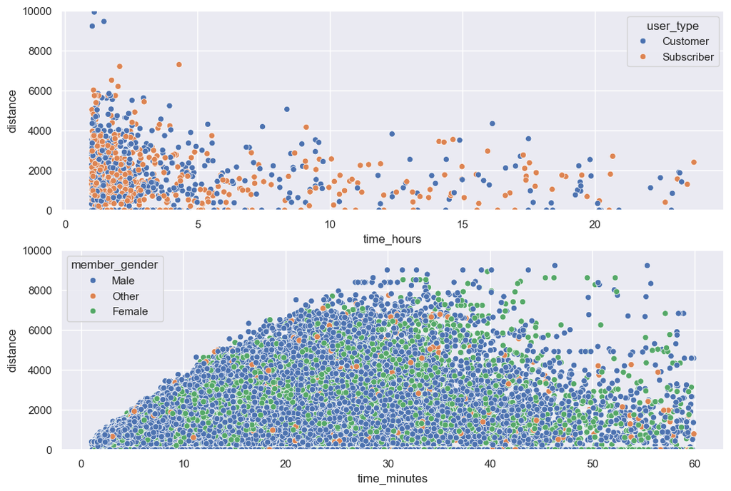

```python
figs, ax = plt.subplots(2, 1, figsize=(12, 8))

sns.scatterplot(df, x='time_hours', y='distance', hue='user_type', ax=ax[0])
ax
ax[0].set_ylim(0, 10000)

sns.scatterplot(df, x='time_minutes', y='distance', hue='member_gender', ax=ax[1])
ax[1].set_ylim(0, 10000)
```

### Were there any interesting or surprising interactions between features?

No.

## Conclusions

#### Converting Notebook

Converting the notebook using nbconvert library.

```python
df.to_pickle('./Datasets/df.pkl')
print("Data Saved as Pickle")
```

[output not shown]

```python
import nbformat
from nbconvert import HTMLExporter

# Load the notebook
with open('Part_I_exploration_template.ipynb') as f:
  notebook = nbformat.read(f, as_version=4)

# Convert the notebook to HTML
html_exporter = HTMLExporter()
html_data, resources = html_exporter.from_notebook_node(notebook)

# Save the HTML output
with open('../Part_I_exploration_template.html', 'w') as f:
  f.write(html_data)
```